# Data analysis tools applied to the evaluation of the effect of density fractionation on silicon content of rice husk.

Maria Candelaria Dorta Delgado - Andres Felipe Beltran

5/13/2021

# Introduction

In this document we review the procedure to process the averaged spectra resulting from experiments that evaluate the effect of extraction at different temperatures and different ionic strengths using data analysis tools.

# Loading data to R

First, we import data from each averaging stage:

```r
ExpT <- read.table('promediosCandi.txt')
colnames(ExpT) <-as.numeric( sub('X', '', colnames(ExpT)) )
```

In the chunk above, spectra corresponding to the first set of samples were loaded to R, in which there are 16 samples and the following variables are evaluated:

- Milling time
- Extraction temperature
- sampling zone (whether the sample is taken from the upper half or the lower half of the pellet formed after centrifugation)

Now, we can load to R the second half of the experiments, in which the ionic strength of the extraction solution is evaluated.

```r
ExpSS <- read.table('SSexp.txt')
colnames(ExpSS) <-as.numeric( sub('X', '', colnames(ExpSS)) )
ExpSS <- ExpSS[,-1869]
```

Then, once we have loaded all the information we needed into R, we can create a new tidy `data.frame` binding rows of `ExpT` and `ExpSS`:

```r
data <- rbind(ExpT,ExpSS)
```

## Plotting imported data.

Employing a for loop, we can plot each row of the data.frame `data` against the names of the columns of `data`. This will plot absorbance data versus the frequency of incident light in $cm-1$ :

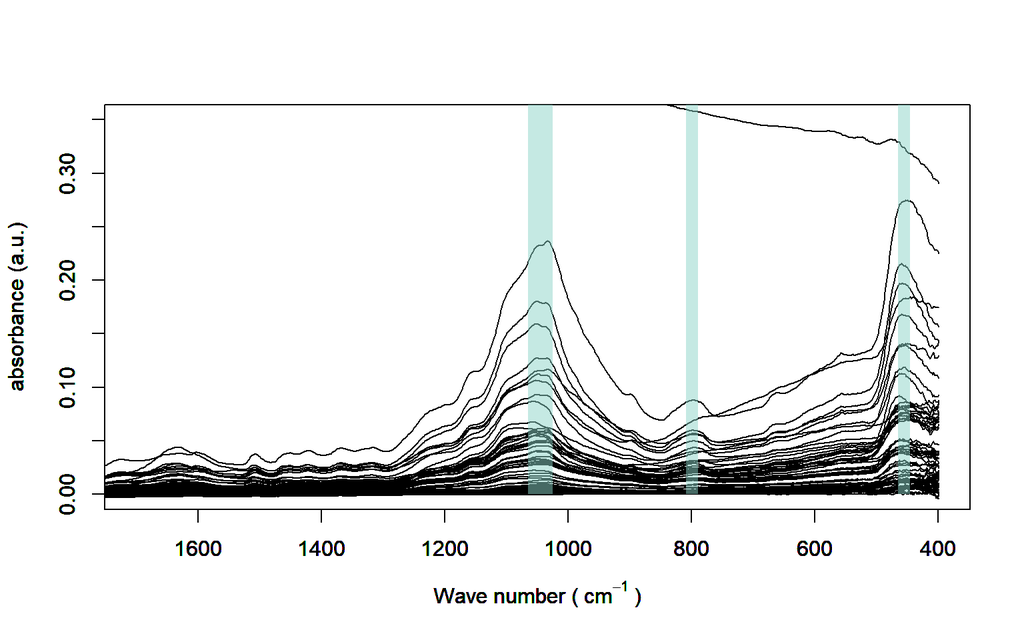

```r
for(i in 1:71){
  plot(colnames(data),
       data[i,],
       type = 'l',
       ylim = c(0,0.35),
       xlim =  c(1700, 400),
       ylab = 'absorbance (a.u.)',
       xlab = expression("Wave number (" ~ cm^-1 ~ ")" ))
  par(new = T)
}
rect(1065,0,1025,1, col= rgb(0.55,0.83,0.78,alpha=0.5), border = NA)
rect(465,0,445,1, col= rgb(0.55,0.83,0.78,alpha=0.5), border = NA)
rect(789,0,809,1, col= rgb(0.55,0.83,0.78,alpha=0.5), border = NA)
```

# Data analysis

## Range selection

Once we have joined all samples’ spectra, we can select a region of interest, to:

- Avoid processing instrumental noise, such as negative values due to atmospheric suppression procedure.
- Analyze only characteristic bands due to Silicon-Oxygen bonds interacting with incident light, such as those bands around 455, 799, and 1045 $1045 \; cm^{-1}$ (Zemnukhova 2015). and those for lignin guaiacyl and syringyl groups from 1700 to 742 $cm^{-1}$ (Heitner 2010).

```r
colnames(data)[c(1,676)]
```

```
## [1] "399.1989" "1700.935"
```

Once we know from which position to which position of the `data,frame` the region of interest is, we can create a subset using the following command:

```r
data <- data[, 1:676]
```

and save a vector containing the corresponding frecuencies for our new region of interest:

```r
wn <- as.numeric( colnames(data[1:676]))
```

## Baseline estimation and correction.

We can get rid of variability given by instrumental noise, employing pre-treatments such as estimation and correction of spectral baseline. This can be done by using the `rubberband` method available in the `hyperspec` R package:

First, we create new `hyperSpec` object called `spc`:

```r
library(hyperSpec)
spc <- new('hyperSpec', spc = data, wavelength = wn)
```

Then we can use the rubberband method to estimate the spectral background and execute the baseline correction. This method was developed for spectra wich show increasing background signal along the abscissa.

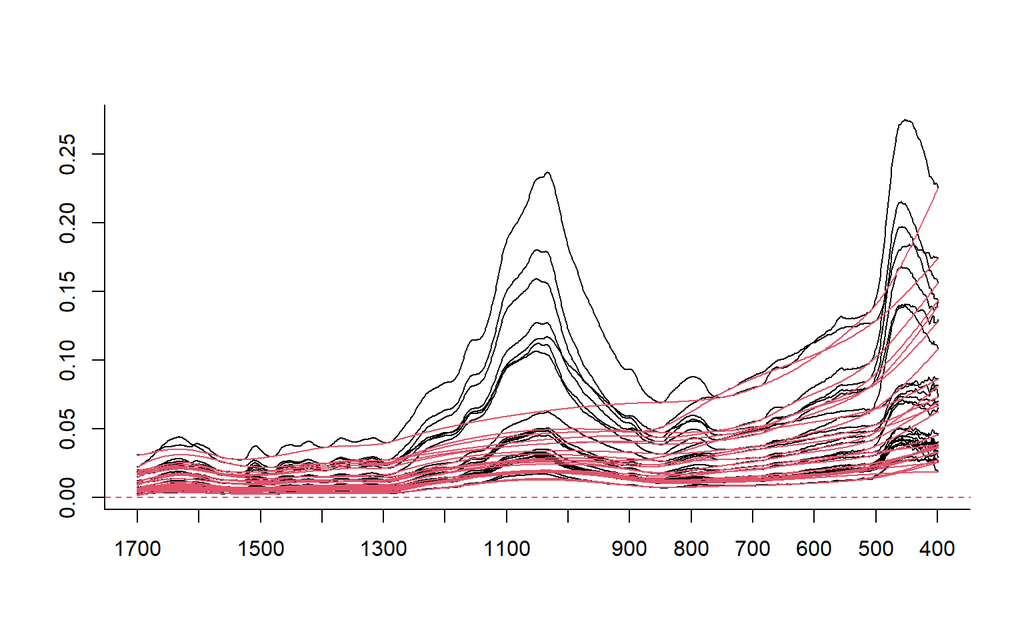

```r
bend <- 0.1 * wl.eval (spc,
                       function (x)
                         x^6+
                         x^5+
                         x^4+
                         x^3+
                         x^2,                       normalize.wl=normalize01)

bl <- spc.rubberband (spc+bend, noise = 1e-4, df=20)-bend
suma <- spc+bend
spc3 <- spc - bl
spc4 <-

plot(spc, wl.reverse = TRUE)
plot(bl, add=TRUE, col=2,wl.reverse = TRUE)
```

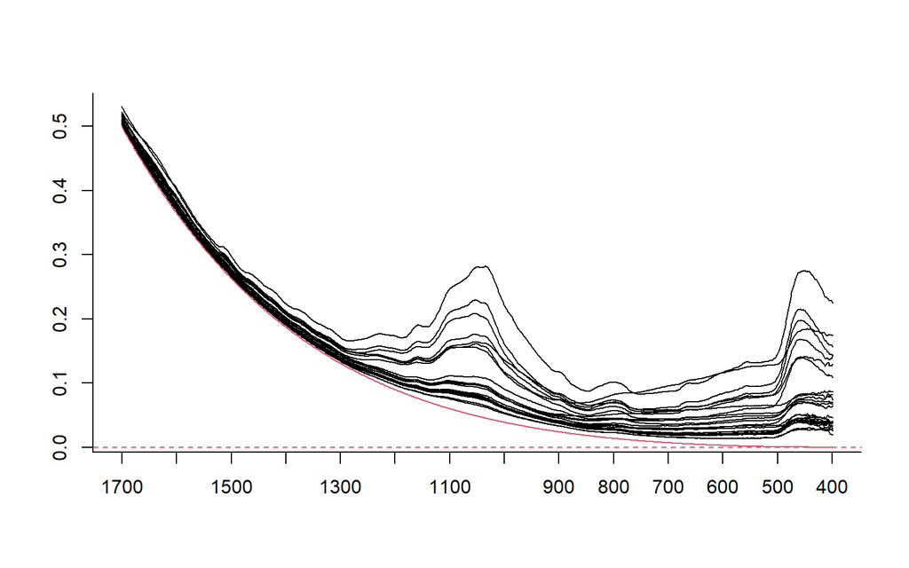

```r
plot(suma,wl.reverse = TRUE)
plot(bend, add=TRUE, col=2,wl.reverse = TRUE)
```

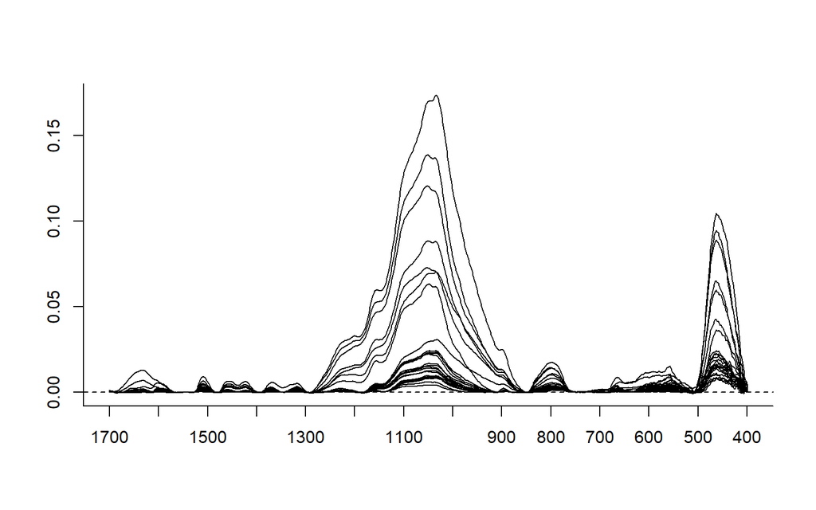

```r
plot(spc3,wl.reverse = TRUE)
```

```r
corregido <- as.data.frame(spc3[1:71])
corregido2 <- as.data.frame(corregido[,1])
```

## Hierarchical analysis with baseline-corrected spectra

### Agrupamiento jerárquico

Esta técnica es útil en las etapas temprandas del análisis, cuando estamos tratando de entender los datos. Por ejemplo, cuando tratamos de encontrar patrones o relaciones entre distitnos factores o variables. Como su nombre lo indica, creamos una jerarquía de grupos.

El agrupamiento jerárquico es una aproximación aglomerativa de abajo hacia arriba. (Varmuza 2016)

El agrupamiento organiza las muestras que están más cerca en grupos. esto depende de varios factores:

- ¿Cómo definimos cerca?
- ¿Cómo agrupamos las muestras?
- ¿Cómo interpretamos el agrupamiento?

```r
library(factoextra)
df <- corregido2
library(factoextra)
res.hk <-hkmeans(df, 6)
names(res.hk)
```

```
##  [1] "cluster"      "centers"      "totss"        "withinss"     "tot.withinss"
##  [6] "betweenss"    "size"         "iter"         "ifault"       "data"
## [11] "hclust"
```

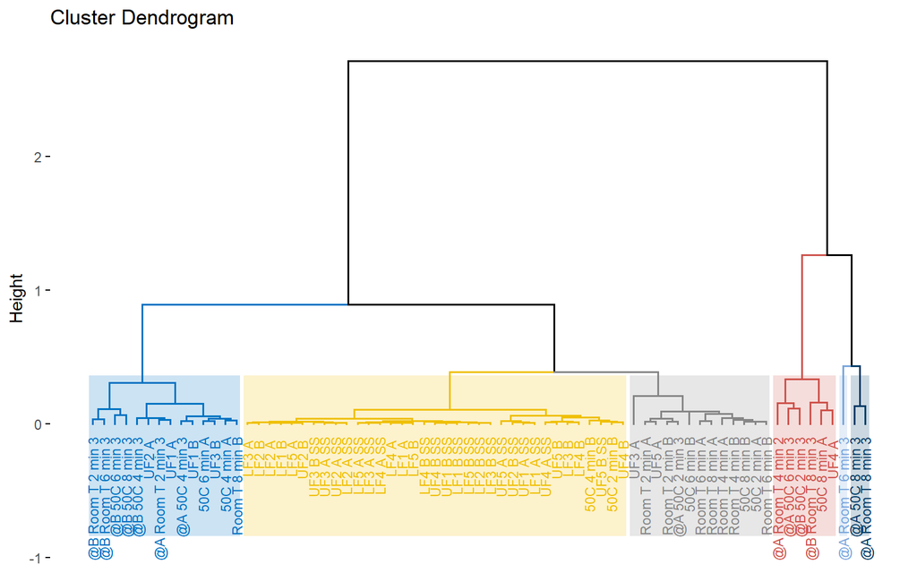

```r
 options(ggrepel.max.overlaps = Inf)
fviz_dend(res.hk, cex = 0.6, palette = "jco",
          rect = TRUE, rect_border = "jco", rect_fill = TRUE)
```

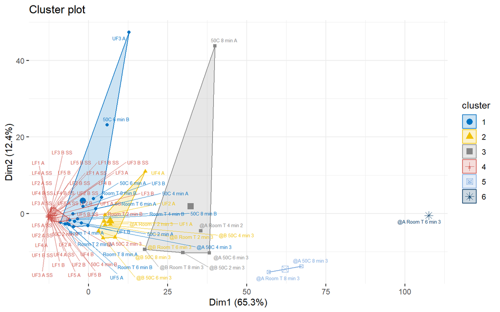

```r
fviz_cluster(res.hk,
             palette = "jco",
             repel = TRUE,
             ggtheme = theme_minimal(),
             labelsize = 6)
```

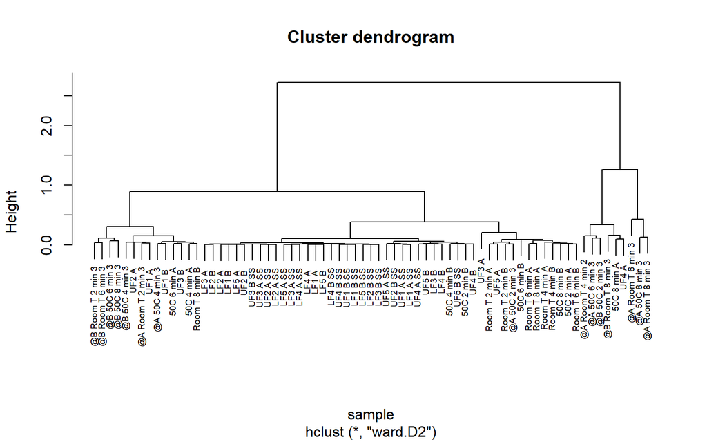

```r
dd <- dist(corregido2, method = "euclidean")
hc <- hclust(dd, method = "ward.D2")
plot(hc,

     main = "Cluster dendrogram",
      xlab = 'sample',
     ylab = "Height",
     cex = 0.6)
```

```r
pca.bl <- prcomp(corregido2, scale =T, center = T)
vp.bl <- (pca.bl$sdev)^2
varianza.bl <- round(vp.bl/sum(vp.bl)*100, 2)
varianza.bl
```

```
##  [1] 65.31 12.35  6.04  5.07  2.40  2.00  1.16  0.99  0.74  0.59  0.53  0.37
## [13]  0.31  0.27  0.25  0.20  0.15  0.14  0.11  0.11  0.09  0.07  0.07  0.07
## [25]  0.05  0.05  0.04  0.04  0.04  0.03  0.03  0.03  0.03  0.02  0.02  0.02
## [37]  0.02  0.02  0.02  0.01  0.01  0.01  0.01  0.01  0.01  0.01  0.01  0.01
## [49]  0.01  0.01  0.01  0.01  0.01  0.01  0.00  0.00  0.00  0.00  0.00  0.00
## [61]  0.00  0.00  0.00  0.00  0.00  0.00  0.00  0.00  0.00  0.00  0.00
```

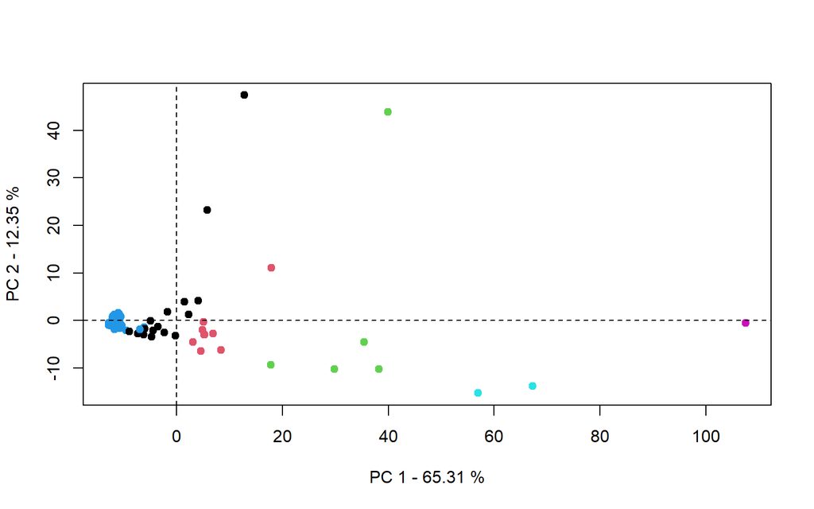

```r
coord <- pca.bl$x

plot(coord[,1],
     coord[,2],
     pch = 19,
     xlab = paste('PC 1 -',as.character(varianza.bl[1]), '%'),
     ylab = paste('PC 2 -',as.character(varianza.bl[2]), '%'),
     col = res.hk$cluster
     )
abline(h = 0, v =  0, lty=2)
```

### OPLS analysis

- Whether the sample is taken from a low or high density fraction
- Whether the sample was extracted in a low or high ionic strengh solution

First, we identificate which samples have `high` or `low` ionic strenght in their extraction solution:

```r
ionic.index <- logical(71)
ionic <- character(71)
for (i in 1:71) {
  ionic.index[i] <- grepl('SS',rownames(df)[i],perl = T)

  if(ionic.index[i] == TRUE){ionic[i] <- 'Hi'}else{ionic[i] <- 'low'}

}
```

```r
density.index <- logical(71)
density <- character(71)
for (i in 1:71) {
  density.index[i] <- grepl('(?=.*UF|@)',rownames(df)[i],perl = T)

  if(density.index[i] == TRUE){density[i] <- 'Low'}else{density[i] <- 'Hi'}

}
density
```

```
##  [1] "Hi"  "Hi"  "Hi"  "Hi"  "Hi"  "Hi"  "Hi"  "Hi"  "Hi"  "Hi"  "Hi"  "Hi"
## [13] "Hi"  "Hi"  "Hi"  "Hi"  "Low" "Low" "Low" "Low" "Low" "Low" "Low" "Low"
## [25] "Low" "Low" "Low" "Low" "Low" "Low" "Low" "Low" "Low" "Low" "Low" "Low"
## [37] "Hi"  "Hi"  "Hi"  "Hi"  "Hi"  "Low" "Low" "Low" "Low" "Low" "Hi"  "Hi"
## [49] "Hi"  "Hi"  "Hi"  "Low" "Low" "Low" "Low" "Low" "Hi"  "Hi"  "Hi"  "Hi"
## [61] "Hi"  "Low" "Low" "Low" "Low" "Low" "Hi"  "Hi"  "Hi"  "Hi"  "Hi"
```

```r
names <- as.character(rownames(df))
dim(names) <- length(rownames(df))
metadata <- data.frame( row.names = names, fraction = as.factor(density), ionic.strength = as.factor(ionic))
```

```r
library(ropls)
df.opls <- opls(df, predI = 4)
```

```
## PCA
## 71 samples x 676 variables
## standard scaling of predictors
##       R2X(cum) pre ort
## Total    0.888   4   0
```

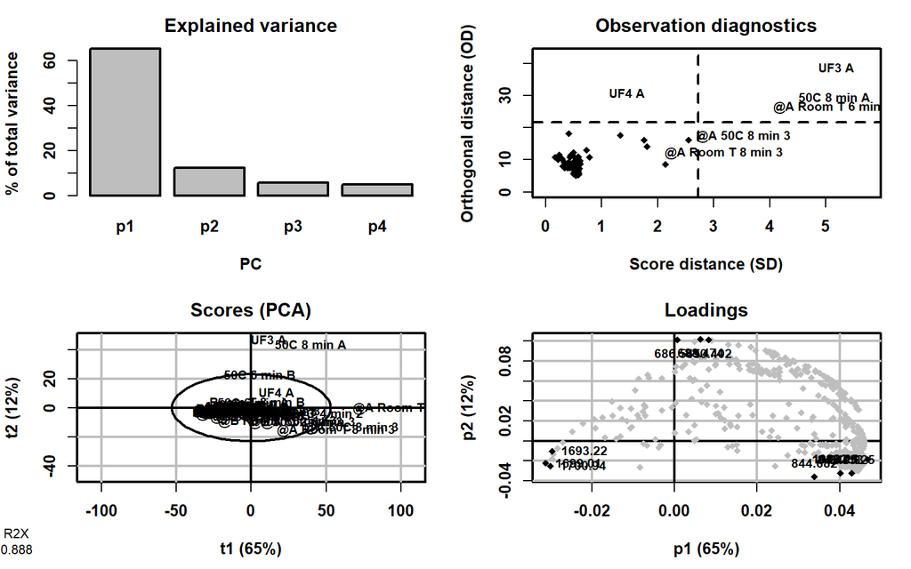

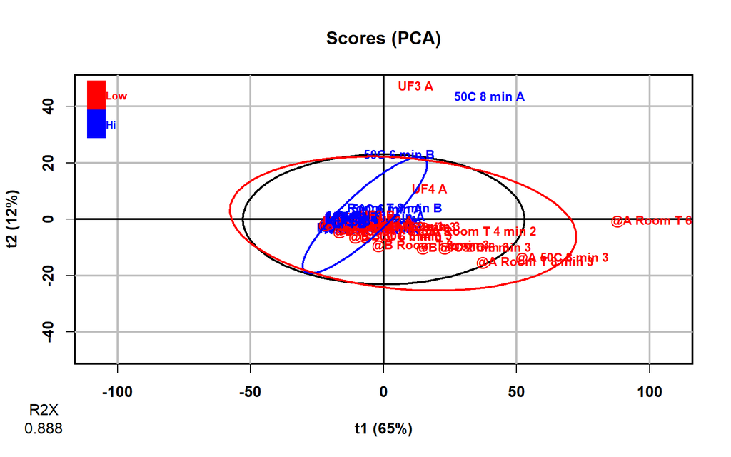

```r
densityFc <- metadata[,'fraction']
plot(df.opls, typeVc = 'x-score', parAsColFcVn = densityFc, parEllipsesL =T)
```

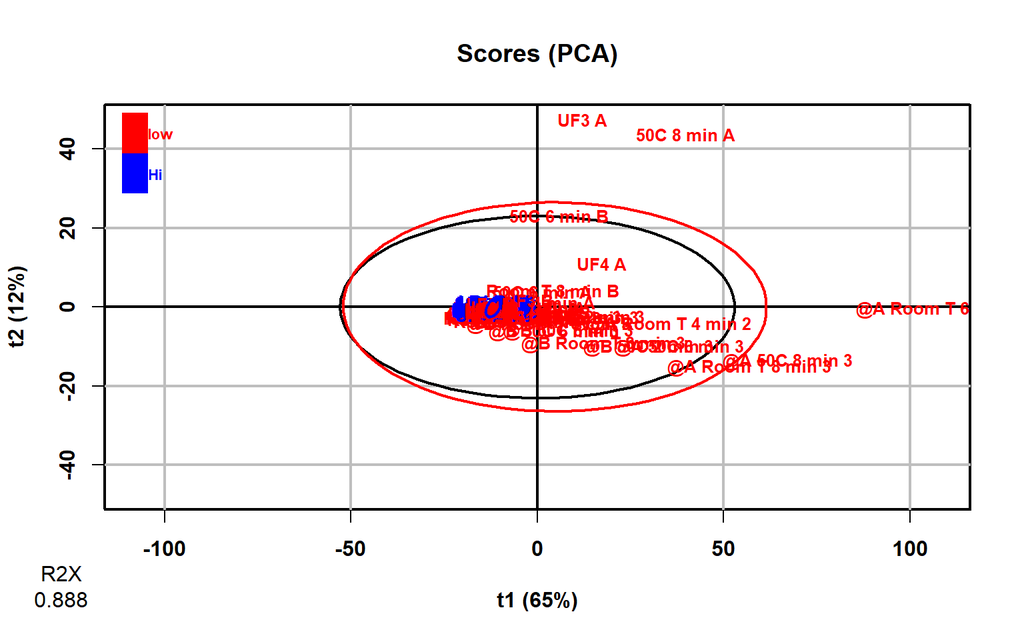

```r
ionicFc <- metadata[,'ionic.strength']
plot(df.opls, typeVc = 'x-score', parAsColFcVn = ionicFc, parEllipsesL =T)
```

```r
density.plsda <- opls(df, densityFc)
```

```
## PLS-DA
## 71 samples x 676 variables and 1 response
## standard scaling of predictors and response(s)
##       R2X(cum) R2Y(cum) Q2(cum) RMSEE pre ort pR2Y  pQ2
## Total    0.846    0.546   0.398 0.349   4   0 0.05 0.05
```

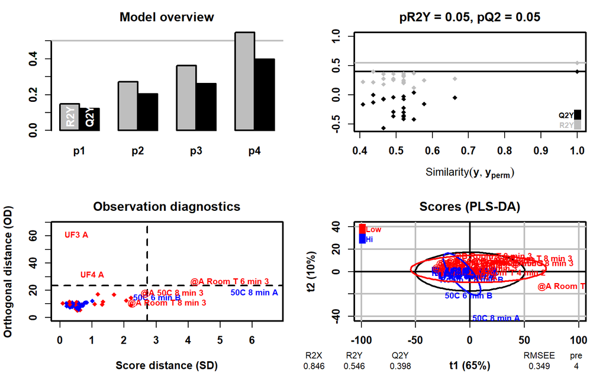

```r
ionic.plsda <- opls(df, ionicFc)
```

```
## PLS-DA
## 71 samples x 676 variables and 1 response
## standard scaling of predictors and response(s)
##       R2X(cum) R2Y(cum) Q2(cum) RMSEE pre ort pR2Y  pQ2
## Total    0.819    0.837   0.779 0.188   4   0 0.05 0.05
```

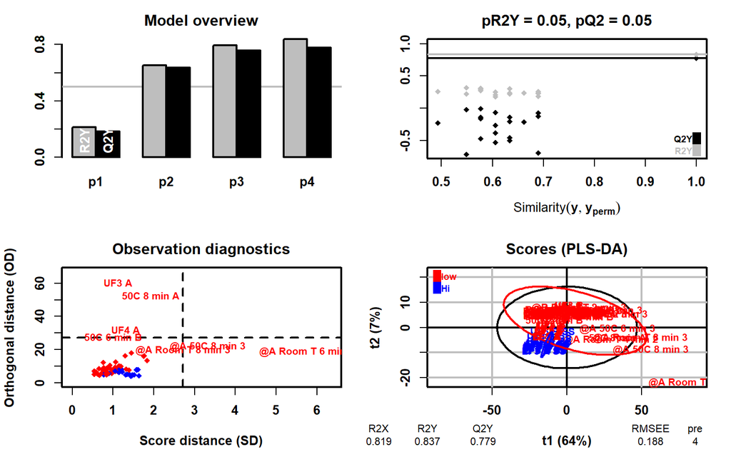

## Análisis exploratorio con corrección de línea base y cálculo de segunda derivada.

A partir de los espectros corregidos contenidos en `corregido2` podemos calcular las segundas derivadas utilizado la función `savitzkyGolay` disponible en el paquete `prospectr`:

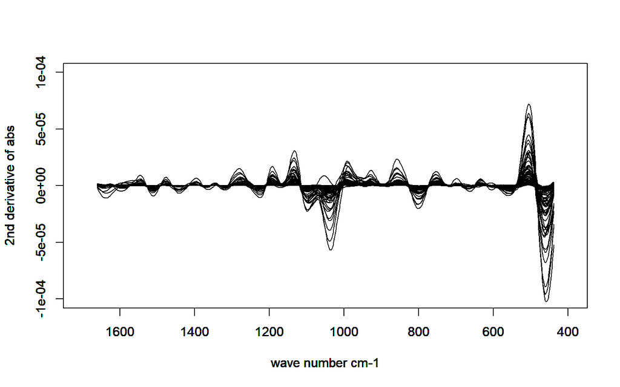

```r
library(prospectr)

w2 <- 40

sg <- matrix(ncol = ncol(corregido2)-w2, nrow= nrow(corregido2))

sg <- as.data.frame(sg)
sg<- savitzkyGolay(X = corregido2
                        ,m = 2,
                        p = 3,
                        w = w2+1,
                        delta.wav=2)
rownames(sg) <- rownames(corregido2)

for(i in 1:length(rownames(sg))){

  plot(as.numeric(colnames(sg)),
       sg[i,],
       xlab = 'wave number cm-1',
       ylab = '2nd derivative of abs',
       xlim = c(1700,400),
        ylim = c(-1e-04,1e-04),
       type = 'l',
       col = 1)
  par(new = T)
}
```

```r
sg.plsda <- opls(sg, ionicFc)
```

```
## PLS-DA
## 71 samples x 636 variables and 1 response
## standard scaling of predictors and response(s)
##       R2X(cum) R2Y(cum) Q2(cum) RMSEE pre ort pR2Y  pQ2
## Total    0.946    0.914   0.741 0.141   8   0 0.05 0.05
```

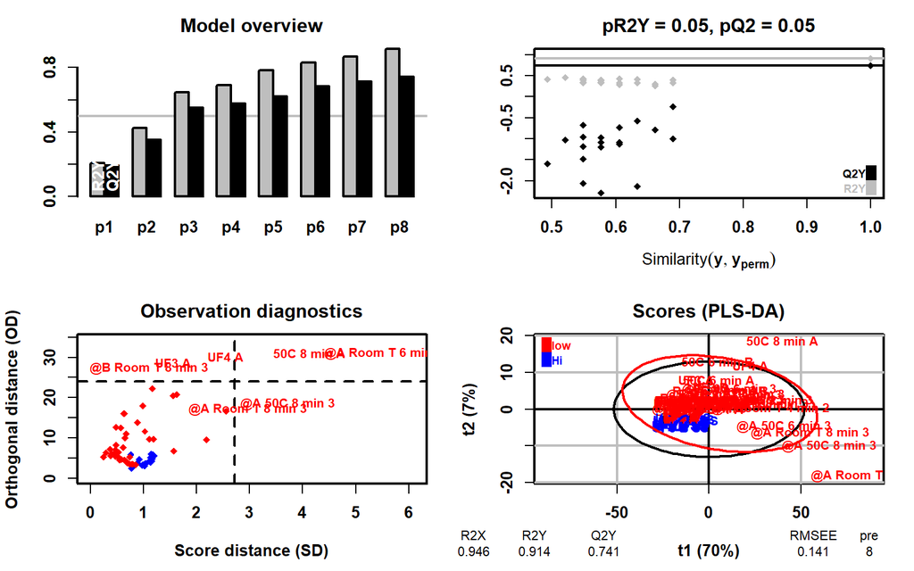

```r
library(factoextra)
df.sg <- sg

res.hk.sg <-hkmeans(df.sg, 4)
names(res.hk.sg)
```

```
##  [1] "cluster"      "centers"      "totss"        "withinss"     "tot.withinss"
##  [6] "betweenss"    "size"         "iter"         "ifault"       "data"
## [11] "hclust"
```

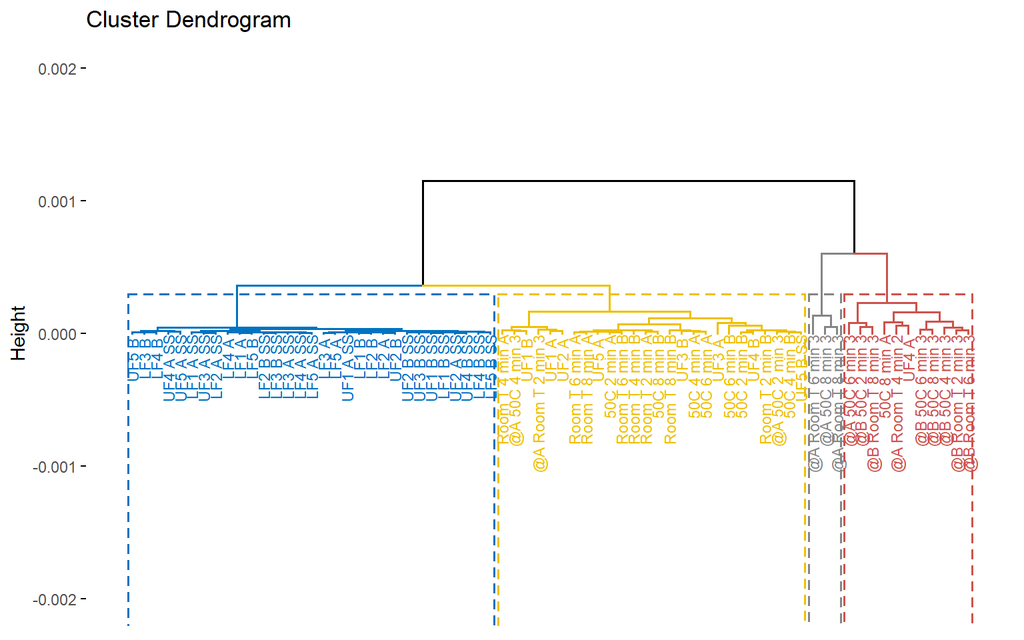

```r
 options(ggrepel.max.overlaps = Inf)

fviz_dend(res.hk.sg,
          cex = 0.6,
          palette = "jco",
          rect = TRUE,
          rect_border = "jco",
          rect_fill = FALSE,
          ylim = c(-0.002, 0.002)
          )
```

```r
pca.bl.2d <- prcomp(sg, scale=T, center = T)

vp.bl.2d <- (pca.bl.2d$sdev)^2
varianza.bl.2d <- round(vp.bl.2d/sum(vp.bl.2d)*100, 2)
varianza.bl.2d
```

```
##  [1] 70.80  9.43  7.37  2.96  1.95  1.93  1.33  1.11  0.57  0.48  0.37  0.29
## [13]  0.22  0.20  0.17  0.15  0.12  0.10  0.08  0.06  0.05  0.04  0.04  0.03
## [25]  0.03  0.02  0.02  0.01  0.01  0.01  0.01  0.01  0.01  0.01  0.00  0.00
## [37]  0.00  0.00  0.00  0.00  0.00  0.00  0.00  0.00  0.00  0.00  0.00  0.00
## [49]  0.00  0.00  0.00  0.00  0.00  0.00  0.00  0.00  0.00  0.00  0.00  0.00
## [61]  0.00  0.00  0.00  0.00  0.00  0.00  0.00  0.00  0.00  0.00  0.00
```

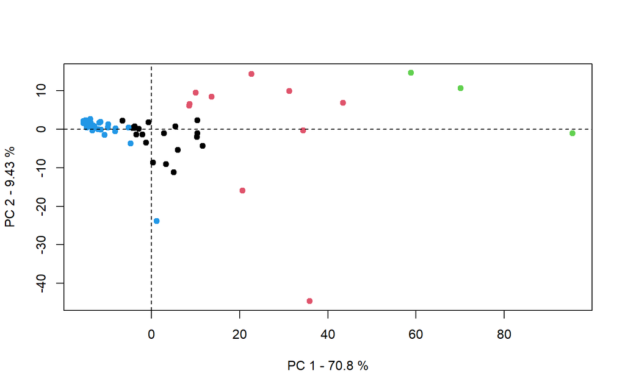

```r
coord.bl.2d <- pca.bl.2d$x

plot(coord.bl.2d[,1],
     coord.bl.2d[,2],
     pch = 19,
     xlab = paste('PC 1 -',as.character(varianza.bl.2d[1]), '%'),
     ylab = paste('PC 2 -',as.character(varianza.bl.2d[2]), '%'),
     col = res.hk.sg$cluster
     )
abline(h = 0, v =  0, lty=2)
```

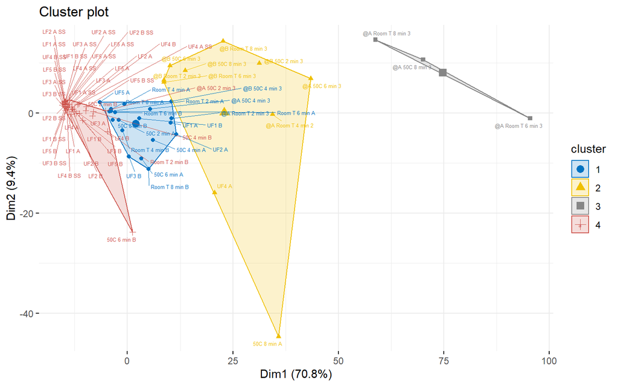

```r
fviz_cluster(res.hk.sg,
             palette = "jco",
             repel = TRUE,
             ggtheme = theme_minimal(),
             labelsize = 5)
```

# Referencias

- Zemnukhova, L. A., Panasenko, A. E., Artem’yanov, A. P., & Tsoy, E. A. (2015). Dependence of porosity of amorphous silicon dioxide prepared from rice straw on plant variety. BioResources, 10(2), 3713-3723.
- Heitner, Cyril, Don Dimmel, and John Schmidt, eds. Lignin and lignans: advances in chemistry. CRC press, 2010, pp 122.
- Varmuza, K., & Filzmoser, P. (2016). Introduction to multivariate statistical analysis in chemometrics. CRC press.